# Test of the different population dispersal

The goal of this notebook is to compare expected population grow and displacement with the results given by QN. To do so, we first implement some general function to move population arround and add grow, and then we simulate them using QN and compare the result

### loading package and setting minimal simulation

```r
devtools::load_all("../RQuantiNemo")
```

```
## Loading RQuantiNemo
```

```r
my_sim.base = new("simulation",sim.dir = "dispersal/")
my_sim.base  <- setParameter(my_sim.base,"generations",75)
my_sim.base  <- setParameter(my_sim.base,"mating_nb_offspring_model",2)
my_sim.base  <- setParameter(my_sim.base,"mean_fecundity",1.1)
my_sim.base  <- setParameter(my_sim.base,"stat","{adlt.nbInd_p }")
```

### Definition of general function to simulate population dispersal and grow in R

#### Computing the number of migrant for a given patch

```r
nMigrantTot <- function(total.rate, n.pop){
  return(rbinom(1,n.pop,total.rate))
}

nMigrant <- function(sum.m, m, n.tot.emigr){
  if (m>0)
  {
    if(m/sum.m < 1) p = m/sum.m else p = 1
  }
  else{
    p = 0
  }
  return(rbinom(1 ,n.tot.emigr, p))
}
```

#### Computing the number of migrant from each to every patches

```r
ComputeEmigr <- function(n.patch, rates, pops){
  nb.migrant.par =  matrix(rep(0,n.patch^2),nrow = n.patch)
  for (patch in 1:n.patch){
    total.rate=sum(rates[patch, ])
    total.rate <- total.rate - rates[patch, patch]
    nb.migrant.tot <- nMigrantTot(total.rate, pops[patch])
    for (patch_migr in 1:n.patch){
      if (patch_migr == patch) {next}
      nb.migrant.par[patch, patch_migr]  <- nMigrant(total.rate, rates[patch, patch_migr], nb.migrant.tot)
      total.rate <- total.rate - rates[patch, patch_migr]
      nb.migrant.tot <- nb.migrant.tot - nb.migrant.par[patch, patch_migr]
    }
  }
  return(nb.migrant.par)
}
```

#### Population grow

```r
ComputeGrow <- function(pops,grow.rate)
{
  return(sapply(pops*grow.rate, rpois, n=1))
}
```

### General settings

```r
n.patch = 12
n.iter = 75
ini.pop = 10
```

## Result

### Migrant Pool island model

#### Common parameters

```r
dispersal.rate = 0.2
```

#### Quantinemo parts

```r
my_sim = my_sim.base
my_sim  <- setParameter(my_sim,"patch_number",12)
my_sim  <- setParameter(my_sim,"patch_ini_size","{20 0 0 0 0 0 0 0 0 0 0 0}")
my_sim  <- setParameter(my_sim,"dispersal_model",0)
my_sim  <- setParameter(my_sim,"replicates",1)
my_sim  <- setParameter(my_sim,"dispersal_rate",dispersal.rate)
my_sim@sim.name <- "migrant_pool"
run(my_sim, verbose = FALSE)
```

```
## [1] 0
```

#### R part

```r
pops=c(20, rep(0, n.patch-1))
popss <- matrix(rep(pops,n.iter),ncol = n.patch)
rates = matrix(rep(dispersal.rate/(n.patch-1),n.patch^2),nrow = n.patch)
diag(rates) = rep(0,n.patch)
for (i in 1:(n.iter-1)){
  nb.migrant.par <- ComputeEmigr(n.patch, rates, pops)
  pops <- pops - colSums(t(nb.migrant.par)) + colSums(nb.migrant.par)
  pops <- ComputeGrow(pops,1.1)
  popss[i+1, ] <- pops
}
```

#### Ploting result

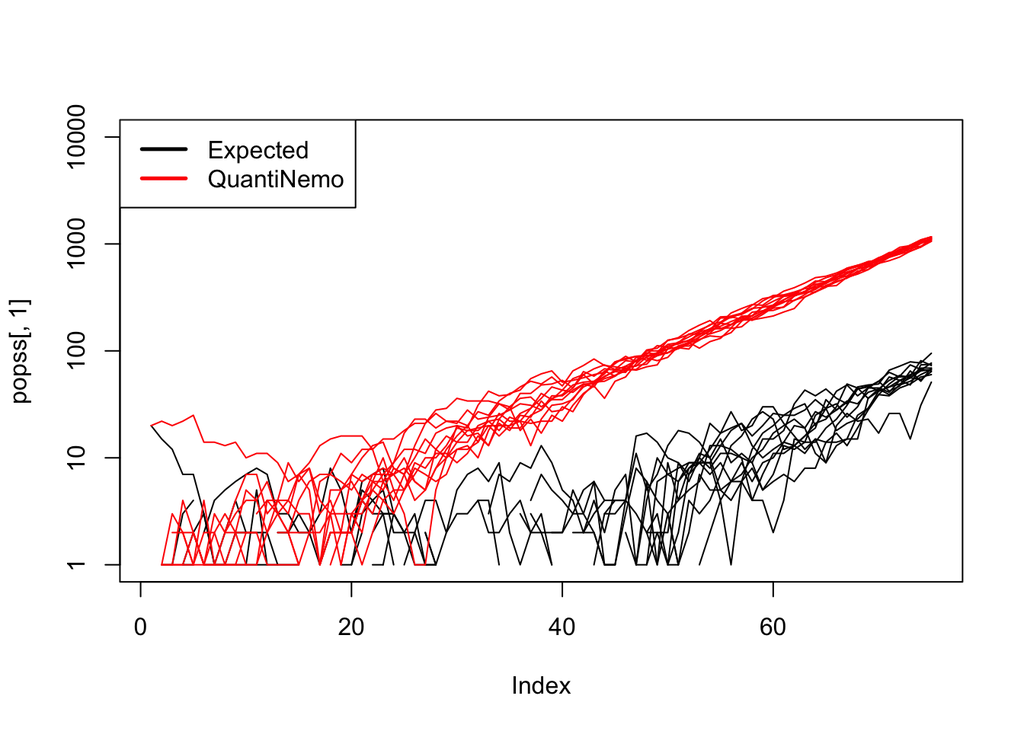

```r
Qn  <- loadStat(my_sim)
plot(popss[, 1], type = "l", log="y",ylim = c(1,10000))
for (patch in 2:n.patch) {lines(popss[, patch])}
final.distrib = rep(0,n.patch)
for (patch in 1:n.patch) {
  var = paste("adlt.nbInd_p",formatC(patch, width = 2,  flag = "0"),sep="")
  lines(Qn[[var]],col="red")
  final.distrib[patch] = tail(Qn[[var]],1)
}
legend("topleft",legend = c("Expected","QuantiNemo"),
lty=c(1,1),
lwd=c(2.5,2.5),
col=c("black","red"))
```

```r
stopifnot(sd(final.distrib) < 150)
```

### 1D stepping stone model

#### Common parameters

```r
dispersal.rate = 0.1
pops = c(15,rep(0,n.patch-1))
```

#### Quantinemo parts

```r
my_sim  <- setParameter(my_sim,"dispersal_model",2)
my_sim  <- setParameter(my_sim,"dispersal_rate",dispersal.rate)
ini_size = paste("{", paste(pops, collapse = " "),"}")
my_sim  <- setParameter(my_sim,"patch_ini_size",ini_size)
my_sim@sim.name <- "1d_stepping_stone"
res <- run(my_sim, verbose = FALSE)
```

#### R parts

```r
#num <- numeric(100)
#num2 <- numeric(100)
#for (k in 1:100){
pops = c(15,rep(0,n.patch-1))
popss <- matrix(rep(pops,n.iter),ncol = n.patch)
rates = matrix(rep(0, n.patch^2),nrow = n.patch)
for (i in 1:n.patch){
  for (j in 1:n.patch){
    if(abs(i-j)==1) rates[i,j ] = 0.5*dispersal.rate
  }
}
#Torus
rates[1, n.patch] <- 0.5*dispersal.rate
rates[n.patch, 1] <- 0.5*dispersal.rate
diag(rates) = rep(0,n.patch)
for (i in 1:(n.iter-1)){
  nb.migrant.par <- ComputeEmigr(n.patch, rates, pops)
  pops <- pops - colSums(t(nb.migrant.par)) + colSums(nb.migrant.par)
  pops <- ComputeGrow(pops,1.1)
  popss[i+1, ] <- pops
}
#num[k] <- sd(pops)
#num2[k] <- mean(pops)
#}
```

#### Ploting result

The result are very similar. The lines are not perfectly align, which might seems strange, but this is due to fluctuation in the early stage of simulation. In on meta-pop, this compensate due to migration, but on two simulation, the overall population might be larger.

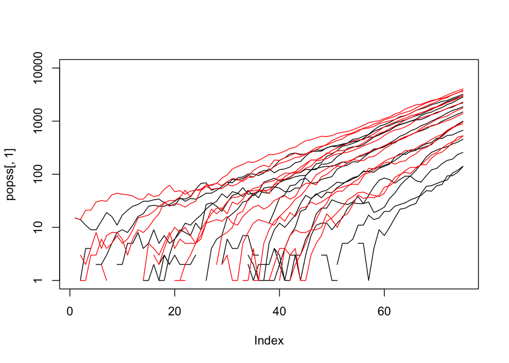

```r
Qn  <- loadStat(my_sim)
plot(popss[, 1], type = "l", log="y",ylim = c(1,10000))
for (patch in 2:n.patch) {lines(popss[, patch])}
  var = paste("adlt.nbInd_p",formatC(1, width = 2,  flag = "0"),sep="")
  #plot(Qn[[var]],col="red", ylim = c(0.1,20000), type = "l")
  final.distrib = rep(0,n.patch)
for (patch in 1:n.patch) {
  var = paste("adlt.nbInd_p",formatC(patch, width = 2,  flag = "0"),sep="")
  lines(Qn[[var]],col="red")
    final.distrib[patch] = tail(Qn[[var]],1)
}
```

```r
 stopifnot(sd(final.distrib)/mean(final.distrib) < 1) #Testing with the R version, it's a cut at about 5%
 stopifnot(sd(final.distrib)/mean(final.distrib) > 0.3) #Testing with the R version, it's a cut at about 5%
```

### 2d stepping stone

#### QuantiNemo part

```r
my_sim  <- setParameter(my_sim,"dispersal_model",3)
my_sim  <- setParameter(my_sim,"generations",40)

my_sim  <- setParameter(my_sim,"dispersal_lattice_range",0)
my_sim  <- setParameter(my_sim,"dispersal_rate",dispersal.rate)
ini_size = paste("{", paste(pops, collapse = " "),"}")
my_sim  <- setParameter(my_sim,"patch_ini_size","{10 0 0 0 0 0 0 0 0 0 0 0}")
my_sim  <- setParameter(my_sim,"replicates",500)
my_sim  <- setParameter(my_sim,"dispersal_lattice_dims","{3 4}")
my_sim@sim.name <- "2d_stepping_stone_4"
sucess <- run(my_sim, verbose = FALSE)
```

We observe here the expected result for a 3x4 lattice. First a single patch is occupied. Then the four first neighboor are occupied and then the five next and finaly the two last patch. Increasing the number of replicates, we can see the structure arrising from the broken rotationnal symmetry of the lattice.

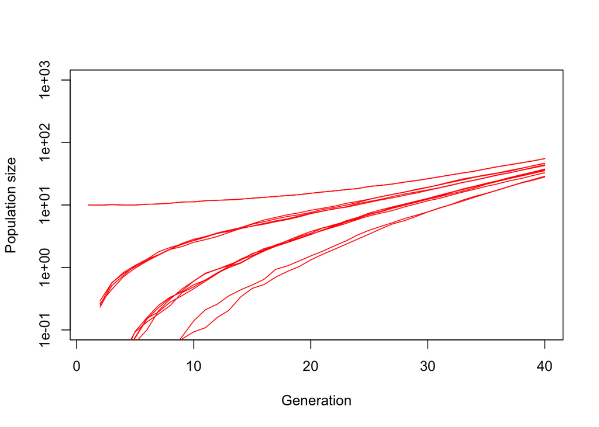

```r
Qn  <- loadStat(my_sim)
final.distrib = rep(0,n.patch)
inter.distrib = rep(0,n.patch)
plot( Qn[["adlt.nbInd_p01"]],col="red", log="y",ylim=c(0.1,1000),type="l",ylab = "Population size", xlab = "Generation")
for (patch in 1:n.patch) {
  var = paste("adlt.nbInd_p",formatC(patch, width = 2,  flag = "0"),sep="")
  lines(Qn[[var]],col="red")
    final.distrib[patch] = tail(Qn[[var]],1)
    inter.distrib[patch] = Qn[[var]][15]
}
```

```r
#Checking that within a distance, variance is small but inbetween, variance is high.
stopifnot(sd(sort(inter.distrib)[1:2]) < 0.2)
stopifnot(sd(sort(inter.distrib)[3:7]) < 0.4)
stopifnot(sd(sort(inter.distrib)[8:11]) < 0.7)
stopifnot(sd(sort(inter.distrib)[1:2]) > 0.005)
stopifnot(sd(sort(inter.distrib)[3:7]) > 0.01)
stopifnot(sd(sort(inter.distrib)[8:11]) > 0.01)
stopifnot(sd(sort(inter.distrib)[1:11]) > 1.6)
```

### 2d stepping stone with 8 neighbor

#### QuantiNemo part

```r
my_sim  <- setParameter(my_sim,"dispersal_model",3)
my_sim  <- setParameter(my_sim,"generations",80)
my_sim  <- setParameter(my_sim,"dispersal_lattice_range",1)
my_sim  <- setParameter(my_sim,"dispersal_rate",dispersal.rate)
ini_size = paste("{", paste(pops, collapse = " "),"}")
my_sim  <- setParameter(my_sim,"patch_ini_size","{10 0 0 0 0 0 0 0 0 0 0 0}")
my_sim  <- setParameter(my_sim,"replicates",100)
my_sim  <- setParameter(my_sim,"dispersal_lattice_dims","{3 4}")
my_sim@sim.name <- "2d_stepping_stone_8"
run(my_sim, verbose = FALSE)
```

```
## [1] 0
```

We observe here the expected result for a 3x4 lattice. First a single patch is occupied. Then the eight first neighboor are occupied and then the three last patch.

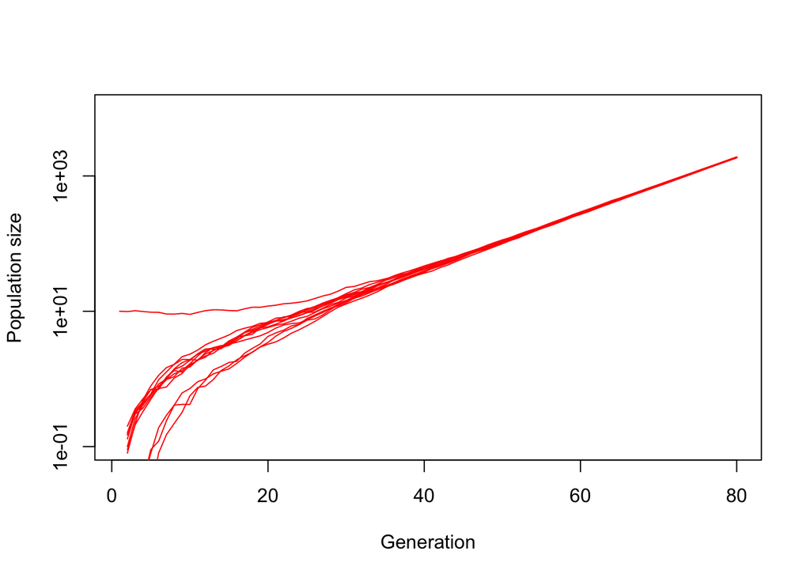

```r
Qn  <- loadStat(my_sim)
final.distrib = rep(0,n.patch)
final.distrib[1] = tail(Qn[["adlt.nbInd_p01"]],1)
plot( Qn[["adlt.nbInd_p01"]],col="red", log="y",ylim=c(0.1,10000),type="l",ylab = "Population size", xlab = "Generation",xlim = c(1,80))
for (patch in 2:n.patch) {
  var = paste("adlt.nbInd_p",formatC(patch, width = 2,  flag = "0"),sep="")
  lines(Qn[[var]],col="red")
    final.distrib[patch] = tail(Qn[[var]],1)
}
```

```r
stopifnot(sd(final.distrib) < 30)
```

### Propagule-pool Island model

#### QuantiNemo part

```r
my_sim  <- my_sim.base
my_sim  <- setParameter(my_sim,"dispersal_model",1)
my_sim  <- setParameter(my_sim,"patch_capacity",1000)
my_sim  <- setParameter(my_sim,"mating_nb_offspring_model",0)
my_sim  <- setParameter(my_sim,"dispersal_propagule_prob",1)
my_sim  <- setParameter(my_sim,"patch_number",6)
my_sim  <- setParameter(my_sim,"generations",2)
my_sim  <- setParameter(my_sim,"replicates",1)
my_sim  <- setParameter(my_sim,"dispersal_rate",0.2)
my_sim  <- setParameter(my_sim,"seed","{10 25}")
my_sim@sim.name <- "propagule"
success <- run(my_sim, verbose = F)
```

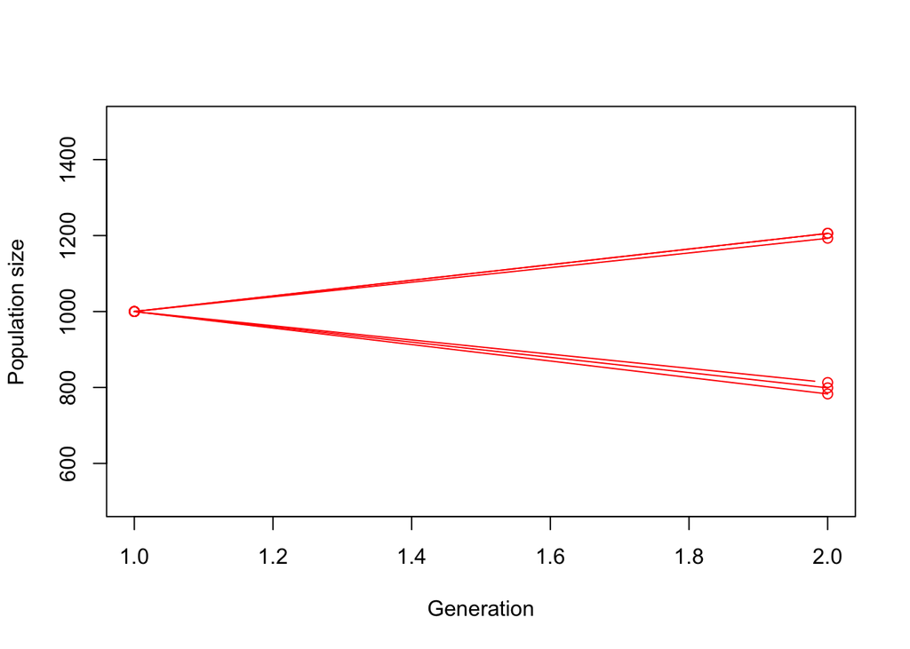

```r
Qn  <- loadStat(my_sim)
var <- "adlt.nbInd_p1"
plot( Qn[[var]],col="red",ylim=c(500,1500),type="b",ylab = "Population size", xlab = "Generation")
final.distrib = rep(0,6)
final.distrib[1] = tail(Qn[[var]],1)
for (patch in 2:6) {
  var = paste("adlt.nbInd_p",formatC(patch, width = 1,  flag = "0"),sep="")
  lines(Qn[[var]],col="red")
  points(Qn[[var]],col="red")
  final.distrib[patch] = tail(Qn[[var]],1)
}
```

```r
#The reason for this statistical test is the following. If we have 6 patch, it is likely that some patches will receive two waves of migration, and some none. As about 0.2*1000 = 200 migrant moves together, some patches will have arround 1200 individuals (or even 1400 or more), and some arround 800. The standard deviation will therefore be large. On the contrary, if we move individual one by one, we do not expect to see so large differences.
stopifnot(sd(final.distrib)>100)
stopifnot(final.distrib == c(813,1206,799,783,1206,1193))
```